# Week 12 Student Lab: Image Classification & Land Cover Mapping — ARIA v8.0

```python
def choose_roi_patches(candidate_mask, score, cls_id, roi_raster, polygons_by_class,
                       target_pixels=600, patch_half=6, max_patches=12):
    """從候選像素中挑選分散且光譜純淨的小區塊。"""
    selected_pixels = 0
    n_grid = 4
    row_edges = np.linspace(0, n_rows, n_grid + 1, dtype=int)
    col_edges = np.linspace(0, n_cols, n_grid + 1, dtype=int)

    cells = []
    for gr in range(n_grid):
        for gc in range(n_grid):
            cells.append((gr, gc))

    # 讓各類別從不同網格起跑，避免所有類別都集中在同一角落。
    cells = cells[cls_id:] + cells[:cls_id]

    for gr, gc in cells:
        if len(polygons_by_class[cls_id]) >= max_patches or selected_pixels >= target_pixels:
            break

        r0, r1 = row_edges[gr], row_edges[gr + 1]
        c0, c1 = col_edges[gc], col_edges[gc + 1]
        block = candidate_mask[r0:r1, c0:c1] & (roi_raster[r0:r1, c0:c1] == -1)
        if np.sum(block) < 10:
            continue

        rr, cc = np.where(block)
        block_scores = score[r0:r1, c0:c1][rr, cc]
        best = int(np.nanargmax(block_scores))
        center_r = int(r0 + rr[best])
        center_c = int(c0 + cc[best])

        pr0 = max(0, center_r - patch_half)
        pr1 = min(n_rows, center_r + patch_half + 1)
        pc0 = max(0, center_c - patch_half)
        pc1 = min(n_cols, center_c + patch_half + 1)
        patch = candidate_mask[pr0:pr1, pc0:pc1] & (roi_raster[pr0:pr1, pc0:pc1] == -1)
        n_patch = int(np.sum(patch))
        if n_patch < 5:
            continue

        roi_raster[pr0:pr1, pc0:pc1][patch] = cls_id
        polygons_by_class[cls_id].append(pixel_box(center_r, center_c, half_size=patch_half))
        selected_pixels += n_patch

    # 若分散小區塊仍不足，補上最高分候選像素，確保每類訓練樣本達標。
    if selected_pixels < 120:
        fill_mask = candidate_mask & (roi_raster == -1)
        rr, cc = np.where(fill_mask)
        if len(rr) > 0:
            order = np.argsort(score[rr, cc])[::-1]
            for idx in order[: max(0, 120 - selected_pixels)]:
                roi_raster[rr[idx], cc[idx]] = cls_id
            polygons_by_class[cls_id].append(pixel_box(int(rr[order[0]]), int(cc[order[0]]), half_size=patch_half))

    return roi_raster


def build_auto_roi():
    """依講義光譜規則建立本機可重現的 pseudo-ROI。"""
    blue, green, red, nir, swir1, swir2 = img
    valid = ~np.any(np.isnan(img), axis=0)
    ndvi = (nir - red) / (nir + red + 1e-10)
    ndwi = (green - nir) / (green + nir + 1e-10)
    ndbi = (swir1 - nir) / (swir1 + nir + 1e-10)
    visible = (blue + green + red) / 3
    col_grid = np.tile(np.arange(n_cols), (n_rows, 1))

    def boxes_mask(boxes):
        mask = np.zeros((n_rows, n_cols), dtype=bool)
        for r0, r1, c0, c1 in boxes:
            mask[max(0, r0):min(n_rows, r1), max(0, c0):min(n_cols, c1)] = True
        return mask

    # 根據真色彩/假色彩影像先給定粗略空間範圍，再用光譜規則挑純淨像素。
    # 這相當於在本機重現 Google Earth 手動畫 ROI 的步驟。
    spatial_priors = {
        0: boxes_mask([(30, 630, 1480, 1755)]),  # 東側外海
        1: boxes_mask([(20, 220, 40, 650), (320, 630, 40, 680), (40, 260, 1250, 1460)]),
        2: boxes_mask([(20, 180, 850, 1160), (300, 500, 820, 1120), (410, 560, 880, 1160)]),
        3: boxes_mask([(235, 335, 600, 1240), (445, 535, 630, 1240), (85, 210, 1070, 1260)]),
        4: boxes_mask([(20, 165, 900, 1160), (315, 385, 780, 1010),
                       (535, 650, 820, 1100), (115, 220, 1100, 1230)]),
    }

    def top_score_mask(base, score, min_pixels=2500, fraction=0.03):
        base = base & np.isfinite(score)
        values = score[base]
        if len(values) == 0:
            return base
        keep = min(len(values), max(min_pixels, int(len(values) * fraction)))
        cutoff = np.partition(values, len(values) - keep)[len(values) - keep]
        return base & (score >= cutoff)

    # 嚴格候選條件：優先選光譜純淨、符合講義物理意義且位置合理的像素。
    candidates = {
        0: valid & spatial_priors[0] & (nir < 0.18) & (swir1 < 0.20),
        1: valid & spatial_priors[1] & (ndvi > 0.45) & (nir > 0.15),
        2: valid & spatial_priors[2] & (ndvi > 0.25) & (ndvi <= 0.55) & (nir > 0.10),
        3: valid & spatial_priors[3] & (ndvi < 0.22) & (visible > 0.22) & (swir1 > 0.28),
        4: valid & spatial_priors[4] & (ndbi > -0.05) & (visible > 0.08) & (visible < 0.30) & (ndvi < 0.35),
    }

    scores = {
        0: (blue - nir) - 2.0 * nir - 1.3 * swir1 - 0.5 * swir2 + 0.4 * ndwi,
        1: 2.0 * ndvi + 0.5 * nir - 2.0 * red,
        2: -np.abs(ndvi - 0.40) + 0.3 * (nir - red),
        3: 2.0 * visible + 1.5 * swir1 + red - 2.0 * ndvi,
        4: 2.0 * ndbi + visible - ndvi - 0.8 * np.maximum(visible - 0.27, 0),
    }

    roi_raster = np.full((n_rows, n_cols), -1, dtype=np.int8)
    polygons_by_class = {i: [] for i in range(N_CLASSES)}

    # 先選最容易純淨的類別，再處理容易與裸地混淆的建物。
    for cls_id in [0, 1, 2, 3, 4]:
        mask = candidates[cls_id] & (roi_raster == -1)
        if int(np.sum(mask)) < 120:
            print(f"  ⚠️ {CLASS_NAMES[cls_id]} 嚴格候選不足，放寬條件。")
            if cls_id == 0:
                # Keep ocean pixels and let the water score choose the lowest NIR/SWIR
                # and strongest Blue-NIR examples.
                mask = top_score_mask(valid & spatial_priors[0], scores[0])
            elif cls_id == 1:
                mask = top_score_mask(valid & spatial_priors[1] & (ndvi > 0.35), scores[1])
            elif cls_id == 2:
                mask = top_score_mask(valid & spatial_priors[2] & (ndvi > 0.18) & (ndvi <= 0.60), scores[2])
            elif cls_id == 3:
                mask = top_score_mask(valid & spatial_priors[3] & (ndvi < 0.32) & (visible > 0.16), scores[3])
            else:
                mask = top_score_mask(valid & spatial_priors[4] & (visible > 0.05) & (ndvi < 0.45), scores[4])
            mask = mask & (roi_raster == -1)

        roi_raster = choose_roi_patches(mask, scores[cls_id], cls_id,
                                        roi_raster, polygons_by_class)

    return roi_raster, polygons_by_class


DEFAULT_KMZ = Path("week12_training_rois.kmz")
kmz_filename = None

if IN_COLAB:
    print("請上傳你在 Google Earth 製作的 KMZ 檔案；若未上傳，將由本 notebook 先建立 KMZ 後再讀取。")
    uploaded = files.upload()
    if uploaded:
        kmz_filename = list(uploaded.keys())[0]
else:
    if DEFAULT_KMZ.exists():
        kmz_filename = str(DEFAULT_KMZ)
```

```
建立 Week 12 訓練樣本 KMZ：week12_training_rois.kmz
KMZ 依據：水體低 NIR/SWIR、森林高 NDVI、農地中等 NDVI、裸地低 NDVI 且 Red/SWIR 可見、建物 NDBI 接近或高於 0。
```

```
已建立 KMZ 訓練樣本檔: week12_training_rois.kmz
使用 KMZ ROI: week12_training_rois.kmz

--- 解析 KMZ ---
```

```
  ✓ Water_01_01_水體 → Water
  ✓ Water_02_01_水體 → Water
  ✓ Water_03_01_水體 → Water
  ✓ Water_04_01_水體 → Water
  ✓ Water_05_01_水體 → Water
  ✓ Forest_01_01_森林 → Forest
  ✓ Forest_02_01_森林 → Forest
  ✓ Forest_03_01_森林 → Forest
  ✓ Forest_04_01_森林 → Forest
  ✓ Forest_05_01_森林 → Forest
  ✓ Forest_06_01_森林 → Forest
  ✓ Forest_07_01_森林 → Forest
  ✓ Agriculture_01_01_農地 → Agriculture
  ✓ Agriculture_02_01_農地 → Agriculture
  ✓ Agriculture_03_01_農地 → Agriculture
  ✓ Agriculture_04_01_農地 → Agriculture
  ✓ Agriculture_05_01_農地 → Agriculture
  ✓ Agriculture_06_01_農地 → Agriculture
  ✓ Agriculture_07_01_農地 → Agriculture
  ✓ Agriculture_08_01_農地 → Agriculture
  ✓ Agriculture_09_01_農地 → Agriculture
  ✓ Agriculture_10_01_農地 → Agriculture
  ✓ Agriculture_11_01_農地 → Agriculture
  ✓ Agriculture_12_01_農地 → Agriculture
  ✓ Agriculture_13_01_農地 → Agriculture
  ✓ Agriculture_14_01_農地 → Agriculture
  ✓ Agriculture_15_01_農地 → Agriculture
  ✓ Agriculture_16_01_農地 → Agriculture
  ✓ Agriculture_17_01_農地 → Agriculture
  ✓ Agriculture_18_01_農地 → Agriculture
  ✓ Agriculture_19_01_農地 → Agriculture
  ✓ Agriculture_20_01_農地 → Agriculture
  ✓ Agriculture_21_01_農地 → Agriculture
  ✓ Agriculture_22_01_農地 → Agriculture
  ✓ Agriculture_23_01_農地 → Agriculture
  ✓ Agriculture_24_01_農地 → Agriculture
  ✓ Agriculture_25_01_農地 → Agriculture
  ✓ Agriculture_26_01_農地 → Agriculture
  ✓ Bare/Landslide_01_01_裸地/崩塌 → Bare/Landslide
  ✓ Bare/Landslide_02_01_裸地/崩塌 → Bare/Landslide
```

[output cut: 47 more lines]

```
  ✓ Built-up_19_01_建物 → Built-up
  ✓ Built-up_20_01_建物 → Built-up
  ✓ Built-up_21_01_建物 → Built-up
  ✓ Built-up_22_01_建物 → Built-up
  ✓ Built-up_23_01_建物 → Built-up
  ✓ Built-up_24_01_建物 → Built-up

=== 訓練樣本統計 ===
總訓練像素數: 2,491

  Class 0 (           Water / 水體):    484 pixels, 5 個 ROI 區塊  ✅
  Class 1 (          Forest / 森林):    687 pixels, 7 個 ROI 區塊  ✅
  Class 2 (     Agriculture / 農地):    593 pixels, 26 個 ROI 區塊  ✅
  Class 3 (  Bare/Landslide / 裸地/崩塌):    332 pixels, 31 個 ROI 區塊  ✅
  Class 4 (        Built-up / 建物):    395 pixels, 24 個 ROI 區塊  ✅
```

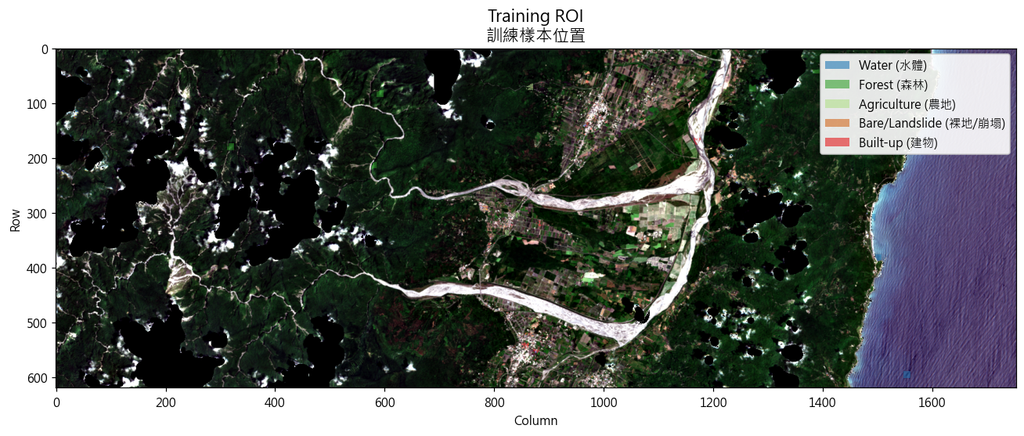

```
ROI 檢查重點：
  - 每類至少 30 pixels，建議 100+ pixels。
  - 光譜規則需符合講義：水體低 NIR/SWIR、森林高 NDVI、裸地低 NDVI、建物 NDBI 較高。
  - 下方 S12b 會進一步檢核樣本數、光譜合理性、類別可分離性與空間分布。
```

```python
if kmz_filename is None:
    print("建立 Week 12 訓練樣本 KMZ：week12_training_rois.kmz")
    print("KMZ 依據：水體低 NIR/SWIR、森林高 NDVI、農地中等 NDVI、裸地低 NDVI 且 Red/SWIR 可見、建物 NDBI 接近或高於 0。")
    roi_seed, _ = build_auto_roi()
    export_roi_raster_to_kmz(roi_seed, DEFAULT_KMZ)
    kmz_filename = str(DEFAULT_KMZ)
    print(f"已建立 KMZ 訓練樣本檔: {kmz_filename}")

print(f"使用 KMZ ROI: {kmz_filename}")
print("\n--- 解析 KMZ ---")
polygons_by_class = parse_kmz(kmz_filename)
roi_raster = rasterize_wgs84_polygons(polygons_by_class)

# --- 提取訓練像素 ---
X_train_list = []
y_train_list = []

for cls_id in range(N_CLASSES):
    cls_mask = (roi_raster == cls_id)
    cls_pixels = img[:, cls_mask].T
    valid_rows = ~np.any(np.isnan(cls_pixels), axis=1)
    cls_valid = cls_pixels[valid_rows]
    if len(cls_valid) > 0:
        X_train_list.append(cls_valid)
        y_train_list.append(np.full(len(cls_valid), cls_id))

if len(X_train_list) != N_CLASSES:
    missing = [CLASS_NAMES[i] for i in range(N_CLASSES) if not np.any(roi_raster == i)]
    raise RuntimeError(f"ROI 樣本缺少類別: {missing}")

X_roi = np.vstack(X_train_list)
y_roi = np.concatenate(y_train_list)

# --- 統計報告 ---
print("\n=== 訓練樣本統計 ===")
print(f"總訓練像素數: {len(y_roi):,}\n")
for cls_id in range(N_CLASSES):
    count = int(np.sum(y_roi == cls_id))
    n_poly = len(polygons_by_class[cls_id])
    status = "✅" if count >= 100 else ("🔶 可用但偏少" if count >= 30 else "⚠️ 偏少，建議增加 ROI")
    print(
        f"  Class {cls_id} ({CLASS_NAMES[cls_id]:>16s} / "
        f"{CLASS_NAMES_ZH[cls_id]}): {count:>6,} pixels, "
        f"{n_poly} 個 ROI 區塊  {status}"
    )

# --- 視覺化 ROI ---
fig, ax = plt.subplots(figsize=(12, 8))
ax.imshow(make_rgb(img, [2, 1, 0]))

roi_colors_vis = ["#1f78b4", "#33a02c", "#b2df8a", "#d2691e", "#e31a1c"]
for cls_id in range(N_CLASSES):
    mask = (roi_raster == cls_id)
    if np.any(mask):
        overlay = np.zeros((*mask.shape, 4))
        c = mcolors.to_rgba(roi_colors_vis[cls_id], alpha=0.5)
        overlay[mask] = c
        ax.imshow(overlay)

legend_roi = [Patch(facecolor=roi_colors_vis[i], alpha=0.6,
                    label=f"{CLASS_NAMES[i]} ({CLASS_NAMES_ZH[i]})")
              for i in range(N_CLASSES)]
ax.legend(handles=legend_roi, loc="upper right", fontsize=10, framealpha=0.9)
ax.set_title("Training ROI\n訓練樣本位置", fontsize=14)
ax.set_xlabel("Column")
ax.set_ylabel("Row")
plt.tight_layout()
plt.show()

print("\nROI 檢查重點：")
print("  - 每類至少 30 pixels，建議 100+ pixels。")
print("  - 光譜規則需符合講義：水體低 NIR/SWIR、森林高 NDVI、裸地低 NDVI、建物 NDBI 較高。")
print("  - 下方 S12b 會進一步檢核樣本數、光譜合理性、類別可分離性與空間分布。")
```

### 🔍 ROI 智慧驗證（Smart ROI Validation）

下方的驗證程式會自動檢查你的訓練樣本品質，模擬專家審查流程：

| 檢查項目 | 說明 |
| --- | --- |
| **樣本數量** | 每類至少需要 30 個像素（建議 100+），依特徵數給出建議值 |
| **光譜合理性** | 檢查各類別的光譜特徵是否符合預期（如水體 NIR 應低、森林 NDVI 應高） |
| **類別可分離性** | 各類別之間光譜是否足夠不同（Jeffries-Matusita 距離） |
| **空間分布** | ROI 是否過度集中在影像某區域 |

執行後會產生一份「診斷報告」，並針對不合格的項目給出具體改善建議。

```
======================================================================
📊  檢查 1／4：樣本數量
======================================================================
             Water (水體):    484 pixels  ✅ 合格
            Forest (森林):    687 pixels  ✅ 充足
       Agriculture (農地):    593 pixels  ✅ 充足
    Bare/Landslide (裸地/崩塌):    332 pixels  ✅ 合格
          Built-up (建物):    395 pixels  ✅ 合格

======================================================================
🌈  檢查 2／4：光譜合理性（各類別光譜是否符合物理預期）
======================================================================
  場景自適應門檻: Water NIR<0.21, Water SWIR1<0.21, Forest Red<0.14

  Water (水體):
    平均光譜: Blue=0.2097 Green=0.2060 Red=0.1784 NIR=0.1594 SWIR1=0.1629 SWIR2=0.1535
    NDVI=-0.056
    ✅ NIR 應低（< 0.21，場景自適應）
    ✅ SWIR 應低（< 0.21，場景自適應）
    ✅ Blue > NIR
    → 光譜特徵合理 👍

  Forest (森林):
    平均光譜: Blue=0.1309 Green=0.1651 Red=0.1315 NIR=0.5644 SWIR1=0.3273 SWIR2=0.1990
    NDVI=0.622
    ✅ NDVI 應高（> 0.4）
    ✅ NIR 應高（> 0.15）
    ✅ Red 應低（< 0.14，場景自適應）
    → 光譜特徵合理 👍

  Agriculture (農地):
    平均光譜: Blue=0.1539 Green=0.1891 Red=0.1682 NIR=0.4109 SWIR1=0.3088 SWIR2=0.2267
    NDVI=0.419
    ✅ NDVI 應為正（> 0.2）
    ✅ NIR 應適中
    → 光譜特徵合理 👍

  Bare/Landslide (裸地/崩塌):
    平均光譜: Blue=0.2499 Green=0.2686 Red=0.2765 NIR=0.3238 SWIR1=0.3866 SWIR2=0.3475
    NDVI=0.079
```

[output cut: 30 more lines]

```
======================================================================
             Water: 空間範圍 77.1% 影像寬度, 5 個多邊形  ✅ 5 個多邊形，分布合理
            Forest: 空間範圍 61.6% 影像寬度, 7 個多邊形  ✅ 7 個多邊形，分布合理
       Agriculture: 空間範圍 70.0% 影像寬度, 26 個多邊形  ✅ 26 個多邊形，分布合理
    Bare/Landslide: 空間範圍 70.6% 影像寬度, 31 個多邊形  ✅ 31 個多邊形，分布合理
          Built-up: 空間範圍 74.7% 影像寬度, 24 個多邊形  ✅ 24 個多邊形，分布合理

======================================================================
📋  綜合評估報告
======================================================================

  👍 大致良好，發現 1 個小問題：
  • Bare/Landslide 與 Built-up 光譜相似（JM=0.90），可能導致混淆。嘗試選擇更具代表性的典型區域。

  修改 KMZ 後重新執行 [S12] 和此 cell 即可更新診斷。
```

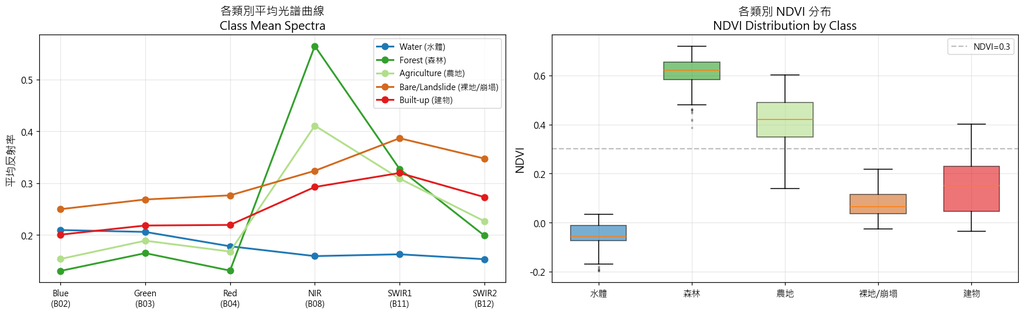

```
左圖：如果兩條曲線形狀幾乎重疊，表示這兩類容易混淆。
右圖：NDVI 分布應該——水體最低、裸地次低、農地中等、森林最高。
```

```python
# =============================================================================
# [S12b] ROI 智慧驗證 — 自動診斷訓練樣本品質 【COMPLETE — 直接執行】
# =============================================================================
# 此程式模擬遙測專家的審查流程，自動檢查你的 ROI 是否適合訓練分類模型。
# 不需修改任何程式碼，直接執行即可看到診斷報告。

import textwrap

# ===================== 1. 樣本數量檢查 =====================
print("=" * 70)
print("📊  檢查 1／4：樣本數量")
print("=" * 70)

# Random Forest 經驗法則：每類至少 10 × 特徵數（6 波段 → 60），建議 100+
MIN_PIXELS = 30       # 最低門檻
REC_PIXELS = 100      # 建議值
GOOD_PIXELS = 500     # 理想值

qty_issues = []
for cls_id in range(N_CLASSES):
    count = int(np.sum(y_roi == cls_id))
    if count == 0:
        grade = "❌ 無樣本"
        qty_issues.append((cls_id, "missing"))
    elif count < MIN_PIXELS:
        grade = f"⚠️ 不足（最少 {MIN_PIXELS}）"
        qty_issues.append((cls_id, "low"))
    elif count < REC_PIXELS:
        grade = f"🔶 偏少（建議 {REC_PIXELS}+）"
        qty_issues.append((cls_id, "marginal"))
    elif count < GOOD_PIXELS:
        grade = "✅ 合格"
    else:
        grade = "✅ 充足"
    print(f"  {CLASS_NAMES[cls_id]:>16s} ({CLASS_NAMES_ZH[cls_id]}): "
          f"{count:>6,} pixels  {grade}")

# ===================== 2. 光譜合理性檢查 =====================
print(f"\n{'=' * 70}")
print("🌈  檢查 2／4：光譜合理性（各類別光譜是否符合物理預期）")
print("=" * 70)

# 波段索引: B02=0, B03=1, B04=2(Red), B08=3(NIR), B11=4(SWIR1), B12=5(SWIR2)
# 場景自適應門檻：若整景反射率底線偏高，使用分位數校正固定門檻。
scene_valid = ~np.any(np.isnan(img), axis=0)
scene_red = img[2][scene_valid]
scene_nir = img[3][scene_valid]
scene_swir1 = img[4][scene_valid]
scene_ndvi = (img[3] - img[2]) / (img[3] + img[2] + 1e-10)
high_ndvi_red = img[2][scene_valid & (scene_ndvi > 0.45)]

water_nir_limit = max(0.10, float(np.nanpercentile(scene_nir, 5)) + 0.05)
water_swir_limit = max(0.08, float(np.nanpercentile(scene_swir1, 5)) + 0.05)
forest_red_limit = max(0.10, float(np.nanpercentile(high_ndvi_red, 25)) + 0.02) if len(high_ndvi_red) else 0.12
print(f"  場景自適應門檻: Water NIR<{water_nir_limit:.2f}, "
      f"Water SWIR1<{water_swir_limit:.2f}, Forest Red<{forest_red_limit:.2f}")
spectral_issues = []

# 計算各類別的波段平均值
class_means = {}
for cls_id in range(N_CLASSES):
    mask_cls = (y_roi == cls_id)
    if np.sum(mask_cls) > 0:
        class_means[cls_id] = X_roi[mask_cls].mean(axis=0)
    else:
        class_means[cls_id] = None

# 定義光譜規則（基於遙測物理原理）
spectral_rules = {
    0: [  # Water
        (f"NIR 應低（< {water_nir_limit:.2f}，場景自適應）", lambda m: m[3] < water_nir_limit,
         "水體強烈吸收近紅外光，NIR 反射率應很低。你的水體 ROI 可能包含了陸地像素。"),
        (f"SWIR 應低（< {water_swir_limit:.2f}，場景自適應）", lambda m: m[4] < water_swir_limit,
         "水體在 SWIR 波段幾乎完全吸收。如果偏高，可能選到了淺水區或河岸。"),
        ("Blue > NIR", lambda m: m[0] > m[3],
         "水體的 Blue 反射率通常高於 NIR。如果不是，可能 ROI 不在水面上。"),
    ],
    1: [  # Forest
        ("NDVI 應高（> 0.4）", lambda m: (m[3] - m[2]) / (m[3] + m[2] + 1e-10) > 0.4,
         "健康森林的 NDVI 通常在 0.5-0.8。偏低可能選到了稀疏植被或混合像素。"),
        ("NIR 應高（> 0.15）", lambda m: m[3] > 0.15,
         "森林的 NIR 反射率應較高（植被結構散射）。"),
        (f"Red 應低（< {forest_red_limit:.2f}，場景自適應）", lambda m: m[2] < forest_red_limit,
         "森林強烈吸收紅光用於光合作用。Red 偏高可能選到了枯萎或裸露區。"),
    ],
    2: [  # Agriculture
        ("NDVI 應為正（> 0.2）", lambda m: (m[3] - m[2]) / (m[3] + m[2] + 1e-10) > 0.2,
         "農地（即使休耕）通常有些植被覆蓋。NDVI 太低可能選到了裸露田地。"),
        ("NIR 應適中", lambda m: m[3] > 0.10,
         "農地的 NIR 反射率應至少適中。"),
    ],
    3: [  # Bare/Landslide
        ("NDVI 應低（< 0.3）", lambda m: (m[3] - m[2]) / (m[3] + m[2] + 1e-10) < 0.3,
         "裸露地表幾乎沒有植被，NDVI 應接近 0 或為負。偏高可能選到了植被恢復區。"),
        ("Red 或 SWIR 應可見", lambda m: m[2] > 0.05 or m[4] > 0.05,
         "裸地在可見光和 SWIR 都有一定反射率。"),
    ],
    4: [  # Built-up
        ("NDBI 應為正或接近 0", lambda m: (m[4] - m[3]) / (m[4] + m[3] + 1e-10) > -0.15,
         "建物的 NDBI（SWIR-NIR 差異）通常高於植被。如果太負，可能選到了公園綠地。"),
        ("整體反射率應適中",
         lambda m: np.mean([m[0], m[1], m[2]]) > 0.04,
         "建物（混凝土、鐵皮屋頂）在可見光有一定反射率。太低可能是陰影或水域。"),
    ],
}

for cls_id in range(N_CLASSES):
    m = class_means[cls_id]
    if m is None:
        print(f"\n  {CLASS_NAMES[cls_id]}: ❌ 無樣本，無法檢查")
        continue

    print(f"\n  {CLASS_NAMES[cls_id]} ({CLASS_NAMES_ZH[cls_id]}):")
    ndvi = (m[3] - m[2]) / (m[3] + m[2] + 1e-10)
    print(f"    平均光譜: Blue={m[0]:.4f} Green={m[1]:.4f} Red={m[2]:.4f} "
          f"NIR={m[3]:.4f} SWIR1={m[4]:.4f} SWIR2={m[5]:.4f}")
    print(f"    NDVI={ndvi:.3f}")

    rules = spectral_rules.get(cls_id, [])
    all_pass = True
    for rule_name, check_fn, advice in rules:
        passed = check_fn(m)
        if passed:
            print(f"    ✅ {rule_name}")
        else:
            print(f"    ⚠️ {rule_name} — 未通過")
            print(f"       💡 {advice}")
            spectral_issues.append((cls_id, rule_name))
            all_pass = False
    if all_pass and len(rules) > 0:
        print(f"    → 光譜特徵合理 👍")

# ===================== 3. 類別可分離性分析 =====================
print(f"\n{'=' * 70}")
print("📐  檢查 3／4：類別可分離性（各類之間是否容易區分）")
print("=" * 70)

# 使用簡化版 Jeffries-Matusita 距離
# JM ∈ [0, 2]：> 1.9 優秀，1.5-1.9 良好，< 1.5 需注意
separability_issues = []

def bhattacharyya_distance(X1, X2):
    """計算兩組樣本的 Bhattacharyya 距離（簡化版）"""
    if len(X1) < 2 or len(X2) < 2:
        return 0.0
    m1, m2 = X1.mean(axis=0), X2.mean(axis=0)
    s1, s2 = np.cov(X1.T) + np.eye(X1.shape[1]) * 1e-6, \
             np.cov(X2.T) + np.eye(X2.shape[1]) * 1e-6
    s_avg = (s1 + s2) / 2
    try:
        sign, logdet = np.linalg.slogdet(s_avg)
        sign1, logdet1 = np.linalg.slogdet(s1)
        sign2, logdet2 = np.linalg.slogdet(s2)
        if sign <= 0 or sign1 <= 0 or sign2 <= 0:
            return 0.0
        dm = m1 - m2
        term1 = 0.125 * dm @ np.linalg.solve(s_avg, dm)
        term2 = 0.5 * (logdet - 0.5 * (logdet1 + logdet2))
        bd = term1 + term2
        jm = 2 * (1 - np.exp(-bd))
        return min(jm, 2.0)
    except np.linalg.LinAlgError:
        return 0.0

print(f"\n  {'':20s}", end="")
for j in range(N_CLASSES):
    print(f"{CLASS_NAMES[j][:8]:>10s}", end="")
print()

for i in range(N_CLASSES):
    print(f"  {CLASS_NAMES[i]:20s}", end="")
    for j in range(N_CLASSES):
        if i == j:
            print(f"{'---':>10s}", end="")
        elif j > i:
            Xi = X_roi[y_roi == i]
            Xj = X_roi[y_roi == j]
            if len(Xi) < 2 or len(Xj) < 2:
                print(f"{'N/A':>10s}", end="")
            else:
                jm = bhattacharyya_distance(Xi, Xj)
                if jm >= 1.9:
                    label = f"{jm:.2f} ✅"
                elif jm >= 1.5:
                    label = f"{jm:.2f} 🔶"
                else:
                    label = f"{jm:.2f} ⚠️"
                    separability_issues.append(
                        (CLASS_NAMES[i], CLASS_NAMES[j], jm))
                print(f"{label:>10s}", end="")
        else:
            print(f"{'':>10s}", end="")
    print()

print(f"\n  判讀：JM 距離 > 1.9 = 容易區分，1.5-1.9 = 尚可，< 1.5 = 易混淆")
if separability_issues:
    print(f"\n  ⚠️ 以下類別對容易混淆：")
    for c1, c2, jm in separability_issues:
        print(f"    • {c1} vs {c2} (JM={jm:.2f})")
        print(f"      💡 建議：選擇更典型的 ROI 區域，或考慮合併這兩類")
else:
    print(f"\n  ✅ 所有類別對的可分離性良好")

# ===================== 4. 空間分布檢查 =====================
print(f"\n{'=' * 70}")
print("🗺️  檢查 4／4：ROI 空間分布（是否過度集中）")
print("=" * 70)

spatial_issues = []
img_center_r, img_center_c = n_rows // 2, n_cols // 2
img_diag = np.sqrt(n_rows**2 + n_cols**2)

for cls_id in range(N_CLASSES):
    mask_cls = (roi_raster == cls_id)
    if not np.any(mask_cls):
        continue
    rows_cls, cols_cls = np.where(mask_cls)
    # 計算 ROI 的空間範圍相對於影像大小
    row_span = (rows_cls.max() - rows_cls.min()) / n_rows
    col_span = (cols_cls.max() - cols_cls.min()) / n_cols
    # 如果所有 ROI 像素都集中在影像的一小塊區域
    spread = max(row_span, col_span)
    n_poly = len(polygons_by_class[cls_id])

    if n_poly == 1 and spread < 0.05:
        status = "⚠️ 僅 1 個小區域，空間代表性不足"
        spatial_issues.append((cls_id, "single_small"))
    elif spread < 0.02:
        status = "⚠️ ROI 過度集中"
        spatial_issues.append((cls_id, "concentrated"))
    elif n_poly >= 2:
        status = f"✅ {n_poly} 個多邊形，分布合理"
    else:
        status = "🔶 建議增加更多分散的 ROI"

    print(f"  {CLASS_NAMES[cls_id]:>16s}: 空間範圍 {spread*100:.1f}% 影像寬度, "
          f"{n_poly} 個多邊形  {status}")

# ===================== 綜合評估報告 =====================
print(f"\n{'=' * 70}")
print("📋  綜合評估報告")
print("=" * 70)

total_issues = len(qty_issues) + len(spectral_issues) + \
               len(separability_issues) + len(spatial_issues)

if total_issues == 0:
    print("\n  🎉 你的 ROI 品質優秀！所有檢查項目都通過了。")
    print("     可以放心進入下一步訓練模型。")
elif total_issues <= 3:
    print(f"\n  👍 大致良好，發現 {total_issues} 個小問題：")
else:
    print(f"\n  ⚠️ 發現 {total_issues} 個問題，建議改善後再訓練模型：")

# 具體改善建議
suggestions = []
for cls_id, level in qty_issues:
    if level == "missing":
        suggestions.append(
            f"• {CLASS_NAMES[cls_id]}：完全沒有樣本！請在 Google Earth 中為此類別"
            f"畫至少 2 個多邊形。")
    elif level == "low":
        suggestions.append(
            f"• {CLASS_NAMES[cls_id]}：像素數不足 {MIN_PIXELS}。"
            f"請畫更大的多邊形或增加更多 ROI 區域。")
    elif level == "marginal":
        suggestions.append(
            f"• {CLASS_NAMES[cls_id]}：像素數偏少。"
            f"建議擴大 ROI 面積至 {REC_PIXELS}+ 像素以提高模型穩定性。")

for cls_id, rule_name in spectral_issues:
    suggestions.append(
        f"• {CLASS_NAMES[cls_id]}：光譜檢查「{rule_name}」未通過。"
        f"請確認 ROI 位置是否正確（可對照真色彩影像）。")

for c1, c2, jm in separability_issues:
    suggestions.append(
        f"• {c1} 與 {c2} 光譜相似（JM={jm:.2f}），"
        f"可能導致混淆。嘗試選擇更具代表性的典型區域。")

for cls_id, issue_type in spatial_issues:
    suggestions.append(
        f"• {CLASS_NAMES[cls_id]}：ROI 空間分布過於集中。"
        f"建議在不同位置多畫幾個多邊形，提高空間代表性。")

for s in suggestions:
    print(f"  {s}")

if total_issues > 0:
    print(f"\n  修改 KMZ 後重新執行 [S12] 和此 cell 即可更新診斷。")
else:
    print(f"\n  ✅ 繼續執行下方的 [S13] 開始訓練 Random Forest 模型吧！")

# ===================== 光譜剖面圖 =====================
fig, axes = plt.subplots(1, 2, figsize=(16, 5))

# 左圖：各類別平均光譜
ax = axes[0]
cls_colors = ["#1f78b4", "#33a02c", "#b2df8a", "#d2691e", "#e31a1c"]
for cls_id in range(N_CLASSES):
    m = class_means[cls_id]
    if m is not None:
        ax.plot(range(n_bands), m, "o-", color=cls_colors[cls_id],
                linewidth=2, markersize=7,
                label=f"{CLASS_NAMES[cls_id]} ({CLASS_NAMES_ZH[cls_id]})")
ax.set_xticks(range(n_bands))
ax.set_xticklabels([f"{BAND_NAMES[i]}\n({BANDS[i]})" for i in range(n_bands)],
                   fontsize=9)
ax.set_ylabel("平均反射率", fontsize=12)
ax.set_title("各類別平均光譜曲線\nClass Mean Spectra", fontsize=13)
ax.legend(fontsize=9, loc="upper right")
ax.grid(True, alpha=0.3)

# 右圖：各類別 NDVI 箱型圖
ax2 = axes[1]
ndvi_by_class = []
labels_bp = []
for cls_id in range(N_CLASSES):
    mask_cls = (y_roi == cls_id)
    if np.sum(mask_cls) > 0:
        cls_data = X_roi[mask_cls]
        ndvi_cls = (cls_data[:, 3] - cls_data[:, 2]) / \
                   (cls_data[:, 3] + cls_data[:, 2] + 1e-10)
        ndvi_by_class.append(ndvi_cls)
        labels_bp.append(f"{CLASS_NAMES_ZH[cls_id]}")
    else:
        ndvi_by_class.append([0])
        labels_bp.append(f"{CLASS_NAMES_ZH[cls_id]}*")

bp = ax2.boxplot(ndvi_by_class, labels=labels_bp, patch_artist=True,
                 widths=0.6, showfliers=True,
                 flierprops=dict(marker=".", markersize=3, alpha=0.3))
for patch, color in zip(bp["boxes"], cls_colors):
    patch.set_facecolor(color)
    patch.set_alpha(0.6)
ax2.set_ylabel("NDVI", fontsize=12)
ax2.set_title("各類別 NDVI 分布\nNDVI Distribution by Class", fontsize=13)
ax2.axhline(y=0.3, color="gray", linestyle="--", alpha=0.5, label="NDVI=0.3")
ax2.legend(fontsize=9)
ax2.grid(True, alpha=0.3)

plt.tight_layout()
plt.show()

print("\n左圖：如果兩條曲線形狀幾乎重疊，表示這兩類容易混淆。")
print("右圖：NDVI 分布應該——水體最低、裸地次低、農地中等、森林最高。")
```

```python
# =============================================================================
# [S13] 訓練 Random Forest 模型 【COMPLETED】
# =============================================================================

# 80/20 分割，保持類別比例（已預先填好）
X_tr, X_te, y_tr, y_te = train_test_split(
    X_roi, y_roi, test_size=0.2, random_state=42, stratify=y_roi
)

print(f"訓練集: {len(y_tr):,} 像素")
print(f"測試集: {len(y_te):,} 像素")

# ── COMPLETED ──
# 1. 建立 Random Forest 分類器
# Hint: RandomForestClassifier(n_estimators=200, max_features="sqrt",
#                              random_state=42, n_jobs=-1, oob_score=True)

rf = RandomForestClassifier(n_estimators=200, max_features="sqrt", random_state=42, n_jobs=-1, oob_score=True)

# 2. 訓練模型
# Hint: 使用 rf.fit(X_tr, y_tr)
print("\n正在訓練 Random Forest（n_estimators=200）...")
rf.fit(X_tr, y_tr)

# 3. 預測測試集並計算精度
# Hint: rf.predict(X_te) 和 accuracy_score(y_te, y_pred_test)
y_pred_test = rf.predict(X_te)
test_acc = accuracy_score(y_te, y_pred_test)
oob_acc = rf.oob_score_  # OOB 精度（Random Forest 內建）

print(f"\n=== 模型評估 ===")
print(f"  Test Accuracy : {test_acc:.4f} ({test_acc * 100:.2f}%)")
print(f"  OOB  Accuracy : {oob_acc:.4f} ({oob_acc * 100:.2f}%)")
# ── END COMPLETED ──

print("\n=== Classification Report ===")
print(classification_report(y_te, y_pred_test, target_names=CLASS_NAMES, digits=4))
```

```
訓練集: 1,992 像素
測試集: 499 像素

正在訓練 Random Forest（n_estimators=200）...
```

```
=== 模型評估 ===
  Test Accuracy : 0.9058 (90.58%)
  OOB  Accuracy : 0.9071 (90.71%)

=== Classification Report ===
                precision    recall  f1-score   support

         Water     0.9898    1.0000    0.9949        97
        Forest     0.9925    0.9638    0.9779       138
   Agriculture     0.8760    0.9496    0.9113       119
Bare/Landslide     0.8060    0.8182    0.8120        66
      Built-up     0.7746    0.6962    0.7333        79

      accuracy                         0.9058       499
     macro avg     0.8878    0.8855    0.8859       499
  weighted avg     0.9050    0.9058    0.9047       499
```

```
正在對全影像進行分類預測...
```

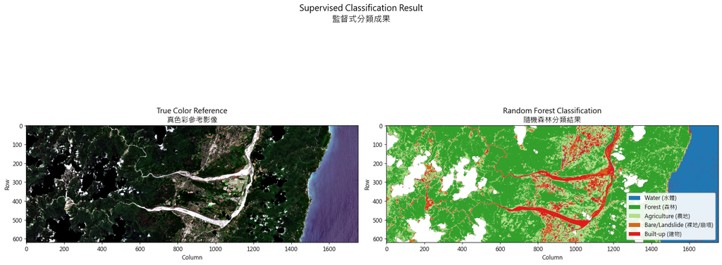

```
分類完成。
```

```python
# =============================================================================
# [S14] 全影像分類 + 分類圖視覺化 【COMPLETED】
# =============================================================================

# --- 分類配色設定（已預先填好）---
lc_colors = [
    "#1f78b4",  # 0: Water — 藍色
    "#33a02c",  # 1: Forest — 深綠
    "#b2df8a",  # 2: Agriculture — 淺綠
    "#d2691e",  # 3: Bare/Landslide — 棕色
    "#e31a1c",  # 4: Built-up — 紅色
]
lc_cmap = mcolors.ListedColormap(lc_colors)
lc_bounds = [-0.5, 0.5, 1.5, 2.5, 3.5, 4.5]
lc_norm = mcolors.BoundaryNorm(lc_bounds, lc_cmap.N)

# ── COMPLETED ──
# 1. 對所有有效像素進行分類預測
# Hint: 使用 rf.predict(pixels_valid)
print("正在對全影像進行分類預測...")
rf_labels = rf.predict(pixels_valid)

# 2. 重建分類圖（將一維結果還原為二維影像）
# Hint: 先建立全 NaN 陣列，再填入預測結果，最後 reshape
class_map_rf = np.full(pixels.shape[0], np.nan)
class_map_rf[valid_pixel_mask] = rf_labels
class_map_rf = class_map_rf.reshape(n_rows, n_cols)
# ── END COMPLETED ──

# --- 視覺化（已預先填好）---
fig, axes = plt.subplots(1, 2, figsize=(18, 8))

# 左：真色彩
axes[0].imshow(true_color)
axes[0].set_title("True Color Reference\n真色彩參考影像", fontsize=13)

# 右：分類結果
im = axes[1].imshow(class_map_rf, cmap=lc_cmap, norm=lc_norm)
axes[1].set_title("Random Forest Classification\n隨機森林分類結果", fontsize=13)

# 圖例
legend_patches = [
    Patch(facecolor=lc_colors[i], label=f"{CLASS_NAMES[i]} ({CLASS_NAMES_ZH[i]})")
    for i in range(N_CLASSES)
]
axes[1].legend(
    handles=legend_patches,
    loc="lower right",
    fontsize=10,
    framealpha=0.9,
    fancybox=True,
)

for ax in axes:
    ax.set_xlabel("Column")
    ax.set_ylabel("Row")

plt.suptitle(
    "Supervised Classification Result\n監督式分類成果", fontsize=15, y=1.02
)
plt.tight_layout()
plt.show()
print("分類完成。")
```

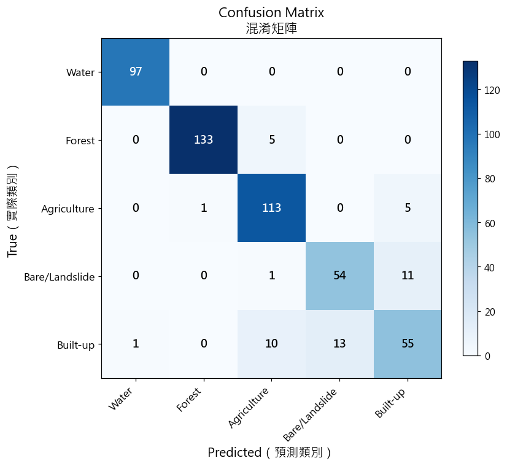

```
Overall Accuracy (OA) : 0.9058 (90.58%)
Cohen's Kappa         : 0.8801

判讀：Kappa > 0.8 為 almost perfect agreement
```

```python
# =============================================================================
# [S15] 混淆矩陣 + OA / Kappa 【COMPLETED】
# =============================================================================

# 計算混淆矩陣（已預先填好）
cm = confusion_matrix(y_te, y_pred_test)

# ── COMPLETED ──
# 1. 繪製混淆矩陣熱力圖
# Hint: 使用 ax.imshow(cm, cmap="Blues") 顯示混淆矩陣
fig, ax = plt.subplots(figsize=(8, 7))
im = ax.imshow(cm, interpolation="nearest", cmap="Blues")
plt.colorbar(im, ax=ax, shrink=0.8)

# 在格子中標註數值
for i in range(N_CLASSES):
    for j in range(N_CLASSES):
        color = "white" if cm[i, j] > cm.max() / 2 else "black"
        ax.text(
            j, i, f"{cm[i, j]}",
            ha="center", va="center",
            fontsize=12, fontweight="bold", color=color,
        )

ax.set_xticks(range(N_CLASSES))
ax.set_yticks(range(N_CLASSES))
ax.set_xticklabels(CLASS_NAMES, rotation=45, ha="right", fontsize=11)
ax.set_yticklabels(CLASS_NAMES, fontsize=11)
ax.set_xlabel("Predicted（預測類別）", fontsize=13)
ax.set_ylabel("True（實際類別）", fontsize=13)
ax.set_title("Confusion Matrix\n混淆矩陣", fontsize=14)
plt.tight_layout()
plt.show()
# ── END COMPLETED ──

# ── COMPLETED ──
# 2. 計算 Overall Accuracy (OA) 和 Cohen's Kappa
# Hint: accuracy_score(y_te, y_pred_test) 和 cohen_kappa_score(y_te, y_pred_test)
OA = accuracy_score(y_te, y_pred_test)
kappa = cohen_kappa_score(y_te, y_pred_test)

print(f"\nOverall Accuracy (OA) : {OA:.4f} ({OA * 100:.2f}%)")
print(f"Cohen's Kappa         : {kappa:.4f}")
print(f"\n判讀：Kappa > 0.8 為 almost perfect agreement")
# ── END COMPLETED ──
```

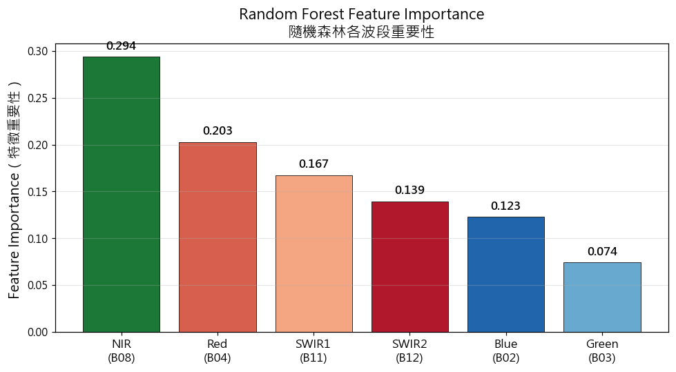

```
=== 特徵重要性排序 ===
  1. NIR    (B08): 0.2937
  2. Red    (B04): 0.2025
  3. SWIR1  (B11): 0.1675
  4. SWIR2  (B12): 0.1394
  5. Blue   (B02): 0.1227
  6. Green  (B03): 0.0741

分析：NIR 和 SWIR 波段通常對土地覆蓋分類最重要，
因為它們能有效區分植被、水體和裸露地表。
```

```python
# =============================================================================
# [S16] 特徵重要性分析 【COMPLETE — 直接執行】
# =============================================================================

importances = rf.feature_importances_
sorted_idx = np.argsort(importances)[::-1]

fig, ax = plt.subplots(figsize=(9, 5))
bar_colors = ["#2166ac", "#67a9cf", "#d6604d", "#1b7837", "#f4a582", "#b2182b"]

bars = ax.bar(
    range(n_bands),
    importances[sorted_idx],
    color=[bar_colors[i] for i in sorted_idx],
    edgecolor="black",
    linewidth=0.5,
)

ax.set_xticks(range(n_bands))
ax.set_xticklabels(
    [f"{BAND_NAMES[i]}\n({BANDS[i]})" for i in sorted_idx], fontsize=11
)
ax.set_ylabel("Feature Importance（特徵重要性）", fontsize=13)
ax.set_title("Random Forest Feature Importance\n隨機森林各波段重要性", fontsize=14)
ax.grid(axis="y", alpha=0.3)

# 在柱狀圖上標數值
for bar_obj, imp in zip(bars, importances[sorted_idx]):
    ax.text(
        bar_obj.get_x() + bar_obj.get_width() / 2,
        bar_obj.get_height() + 0.005,
        f"{imp:.3f}",
        ha="center", va="bottom", fontsize=11, fontweight="bold",
    )

plt.tight_layout()
plt.show()

print("\n=== 特徵重要性排序 ===")
for rank, idx in enumerate(sorted_idx):
    print(f"  {rank + 1}. {BAND_NAMES[idx]:6s} ({BANDS[idx]}): {importances[idx]:.4f}")

print("\n分析：NIR 和 SWIR 波段通常對土地覆蓋分類最重要，")
print("因為它們能有效區分植被、水體和裸露地表。")
```

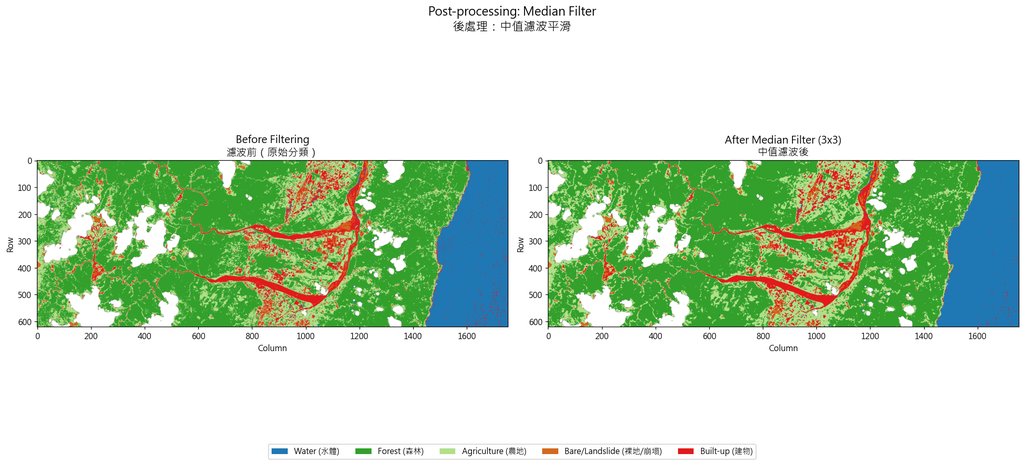

```
變更像素數: 57,419 / 982,254 (5.85%)
中值濾波可消除零碎的 salt-and-pepper 雜訊，使分類結果更平滑。
```

```python
# =============================================================================
# [S17] 後處理 — 中值濾波 【COMPLETED】
# =============================================================================

# ── COMPLETED ──
# 1. 將分類圖中的 NaN 暫時填充為 -1，轉為整數
# Hint: np.nan_to_num(class_map_rf, nan=-1).astype(np.int8)
map_for_filter = np.nan_to_num(class_map_rf, nan=-1).astype(np.int8)

# 2. 套用 3x3 中值濾波
# Hint: median_filter(map_for_filter, size=3)
map_filtered = median_filter(map_for_filter, size=3)

# 3. 恢復 NaN
class_map_filtered = map_filtered.astype(float)
class_map_filtered[map_for_filter == -1] = np.nan
# ── END COMPLETED ──

# 計算變更像素數（已預先填好）
valid_comparison = (~np.isnan(class_map_rf)) & (~np.isnan(class_map_filtered))
pixels_changed = int(
    np.sum(class_map_rf[valid_comparison] != class_map_filtered[valid_comparison])
)
total_valid = int(np.sum(valid_comparison))

# --- 前後比較 ---
fig, axes = plt.subplots(1, 2, figsize=(18, 8))

axes[0].imshow(class_map_rf, cmap=lc_cmap, norm=lc_norm)
axes[0].set_title("Before Filtering\n濾波前（原始分類）", fontsize=13)

axes[1].imshow(class_map_filtered, cmap=lc_cmap, norm=lc_norm)
axes[1].set_title("After Median Filter (3x3)\n中值濾波後", fontsize=13)

for ax in axes:
    ax.set_xlabel("Column")
    ax.set_ylabel("Row")

# 共用圖例
fig.legend(
    handles=legend_patches,
    loc="lower center",
    ncol=5,
    fontsize=10,
    framealpha=0.9,
    bbox_to_anchor=(0.5, -0.02),
)

plt.suptitle("Post-processing: Median Filter\n後處理：中值濾波平滑", fontsize=15)
plt.tight_layout()
plt.show()

print(f"變更像素數: {pixels_changed:,} / {total_valid:,} ({pixels_changed / total_valid * 100:.2f}%)")
print("中值濾波可消除零碎的 salt-and-pepper 雜訊，使分類結果更平滑。")
```

## 反思問題與回答

### 1. K-means 和 Random Forest 結果的最大差異是什麼？

K-means 是非監督式分群，只能依 6 個波段在 feature space 中的距離把像素分成 K 群；cluster 本身沒有地物名稱，必須再由人類根據平均光譜與影像判讀。本次 K-means 把植被分成兩個高 NDVI 群，也把低 NDVI 的裸地/混合像素分成不同群，但不能直接給出「水體、森林、農地、崩塌、建物」名稱。Random Forest 使用 KMZ ROI 訓練樣本後，輸出直接帶有土地覆蓋語意，且本次 OA=90.58%、Kappa=0.8801，適合做可評估的土地覆蓋圖。

### 2. 哪些類別最容易混淆？為什麼？

本次最明顯的殘留混淆是 Bare/Landslide vs. Built-up，ROI 可分離性 JM=0.90，分類報告中 Built-up recall 也較低（約 69.62%）。原因是裸露河床、崩塌裸地、道路與建物屋頂在 Red/SWIR 反射率上都偏亮，20 m 像素又常混合道路、屋頂、空地與植被。這正符合講義錯誤分析中「裸地 vs. 建物光譜類似」的情況。

### 3. 如果你是指揮官，你最在乎哪個類別的 accuracy？

在 2024 花蓮地震災害應變情境中，我最在乎裸地/崩塌類別的 Producer's Accuracy（Recall）。因為崩塌地漏報代表實際受災區沒有被找出來，可能延誤搜救、道路搶通與風險管制。本次 Bare/Landslide recall 約 81.82%，代表多數崩塌/裸露樣本能被找出；但仍要注意它與 Built-up 的混淆，避免把道路、建物或河床誤判成災害裸地。